# Métricas de Paisaje con R

¿Se ha fragmentado la cuenca del río Pilpilco entre 2000 y 2022?

Author

M. Ortiz

# 1 Introducción

## 1.1 Contexto

La fragmentación del paisaje puede modificar el tamaño de los hábitats, la conectividad, los efectos de borde y la diversidad biológica. En esta actividad utilizaremos datos de MapBiomas para evaluar cambios en la cuenca del río Pilpilco entre 2000 y 2022.

**NoteObjetivos**

- Preparar datos espaciales para análisis de paisaje.
- Comprender la importancia de los sistemas de referencia (CRS).
- Calcular métricas a nivel de parche, clase y paisaje.
- Interpretar evidencia de fragmentación.
- Comunicar resultados ecológicos.

# 2 La pregunta ecológica

¿Se ha fragmentado la cuenca del río Pilpilco entre 2000 y 2022?

# 3 Preparación

```r
gc()
```

```
          used (Mb) gc trigger (Mb) max used (Mb)
Ncells  593771 31.8    1353265 72.3   686445 36.7
Vcells 1082757  8.3    8388608 64.0  1875920 14.4
```

```r
rm(list = ls())

library(landscapemetrics)
library(tidyverse)
library(terra)
library(tidyterra)
library(cowplot)
```

# 4 Carga de datos

```r
cuencas_biobio <- vect("cuencas_biobio.shp")

lc_2000 <- rast("chile_coverage_2000.tif")
lc_2022 <- rast("chile_coverage_2022.tif")
```

## 4.1 Exploración inicial

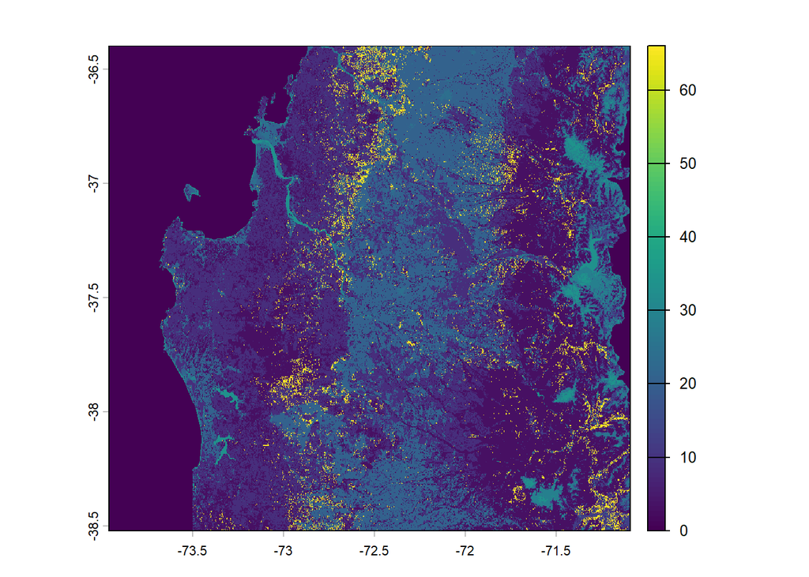

```r
biobio_00 <- crop(lc_2000, cuencas_biobio)
biobio_22 <- crop(lc_2022, cuencas_biobio)

plot(biobio_00)
```

# 5 Un problema frecuente: CRS

Intentemos aplicar una máscara.

```r
biobio_m <- mask(biobio_00, cuencas_biobio)
```

¿Por qué falla?

```r
crs(cuencas_biobio)
```

```
[1] "GEOGCRS[\"GCS_SIRGAS-Chile\",\n    DATUM[\"SIRGAS-Chile realization 1 epoch 2002\",\n        ELLIPSOID[\"GRS 1980\",6378137,298.257222101,\n            LENGTHUNIT[\"metre\",1]],\n        ID[\"EPSG\",1064]],\n    PRIMEM[\"Greenwich\",0,\n        ANGLEUNIT[\"Degree\",0.0174532925199433]],\n    CS…
```

```r
crs(cuencas_biobio) <- crs(biobio_00)
```

## 5.1 Aplicar máscara

```r
biobio_00_m <- mask(biobio_00, cuencas_biobio)
biobio_22_m <- mask(biobio_22, cuencas_biobio)
```

# 6 Selección de la cuenca

## 6.1 ¿Qué subcuencas existen?

```r
cuencas_biobio$NOM_SUBC
```

```
 [1] "Costeras entre R. Itata y R.  Pingueral (Incl.)"
 [2] "Costeras entre Rio Pingueral Y Rio Andalien"
 [3] "Isla Quiriquina"
 [4] "Costeras entre Rio Andalien Y Rio Bio-Bio"
 [5] "Rio Andalien"
 [6] "Rio Bio-Bio Bajo"
 [7] "Rio Itata Alto (Hasta Rio Diguillin)"
 [8] "Laja Bajo"
 [9] "Costeras entre Rio Bio-Bio y Rio Manco"
[10] "Rio Laja Alto (hasta bajo junta Rio Rucue)"
[11] "Isla Santa Maria"
[12] "Costeras entre R. Manco (incl.) y R. Laraquete"
[13] "Rio Lia"
[14] "Costeras entre R. Laraquete (incl.) y R. Carampangue"
[15] "Costeras entre Rio Carampangue y Punta Lavapie"
```

[output cut: 21 more lines]

Trabajaremos con la cuenca del río Pilpilco.

```r
pilpilco <- subset(
  cuencas_biobio,
  cuencas_biobio$NOM_SUBC == "Rio Pilpilco"
)

ventana_zoom <- ext(pilpilco)

pilpilco_00 <- crop(biobio_00, ventana_zoom)
pilpilco_22 <- crop(biobio_22, ventana_zoom)

pilpilco_00 <- mask(pilpilco_00, pilpilco)
pilpilco_22 <- mask(pilpilco_22, pilpilco)


#con pipe (más avanzado)
# pilpilco_00<-biobio_00 %>%
#   crop(ventana_zoom) %>%
#   mask(pilpilco)

#con pipe (más avanzado)
# pilpilco_22<-biobio_22 %>%
#   crop(ventana_zoom) %>%
#   mask(pilpilco)
```

**TipPregunta**

¿Cuál es la diferencia entre `crop()` y `mask()`?

# 7 ¿Está listo el paisaje para landscapemetrics?

```r
check_landscape(pilpilco_00)
```

```
  layer        crs   units   class n_classes OK
1     1 geographic degrees integer         8  ✖
```

```r
check_landscape(pilpilco_22)
```

```
Warning: Caution: Coordinate reference system not metric - Units of results
based on cellsizes and/or distances may be incorrect.
```

```
  layer        crs   units   class n_classes OK
1     1 geographic degrees integer         7  ✖
```

**Warning**

Dice “No OK”. En este caso, las métricas de paisaje requieren coordenadas proyectadas (metros), no coordenadas geográficas (grados).

## 7.1 Reproyección a UTM 18S

```r
target_crs <- "EPSG:32718" #UTM 18S

pil_00 <- project(pilpilco_00, target_crs, method = "near")
pil_22 <- project(pilpilco_22, target_crs, method = "near")

check_landscape(pil_00)
```

```
  layer       crs units   class n_classes OK
1     1 projected     m integer         8  ✔
```

```r
check_landscape(pil_22)
```

```
  layer       crs units   class n_classes OK
1     1 projected     m integer         7  ✔
```

### 7.1.1 Discusión

¿Por qué utilizamos `method = "near"` y no interpolación bilineal?

# 8 Explorando el paisaje

## 8.1 Mapas con la leyenda oficial de MapBiomas

Primero, cargar la leyenda, averiguar formato y filtrar por clases presentes.

```r
leyenda_completa <- read.csv("leyenda_completa.csv")

pil_00 <- as.int(pil_00)
pil_22 <- as.int(pil_22)

valores_presentes <- unique(values(pil_00))
leyenda_filtrada1 <- leyenda_completa %>%
  filter(class %in% valores_presentes)

levels(pil_00) <- leyenda_filtrada1

valores_presentes <- unique(values(pil_22))
leyenda_filtrada2 <- leyenda_completa %>%
  filter(class %in% valores_presentes)

levels(pil_22) <- leyenda_filtrada2
```

Después, graficar con ggplot:

```r
# 2000
p1 <- ggplot() +
  geom_spatraster(data = pil_00, aes(fill = descripcion)) +
  scale_fill_manual(
    values = leyenda_filtrada1$color,
    breaks = leyenda_filtrada1$descripcion,
    name = "Cobertura MapBiomas",
    na.value = "transparent"
  ) +
  theme_minimal() +
  labs(
    title = "Cobertura de Suelo - Cuenca Pilpilco 2000",
    subtitle = "Datos de MapBiomas"
  )
```

```
<SpatRaster> resampled to 500888 cells.
```

```r
#2022

p2 <- ggplot() +
  geom_spatraster(data = pil_22, aes(fill = descripcion)) +
  scale_fill_manual(
    values = leyenda_filtrada2$color,
    breaks = leyenda_filtrada2$descripcion,
    name = "Cobertura MapBiomas",
    na.value = "transparent"
  ) +
  theme_minimal() +
  labs(
    title = "Cobertura de Suelo - Cuenca Pilpilco 2022",
    subtitle = "Datos de MapBiomas"
  )
```

```
<SpatRaster> resampled to 500888 cells.
```

Visualizar individualmente, y en un solo gráfico

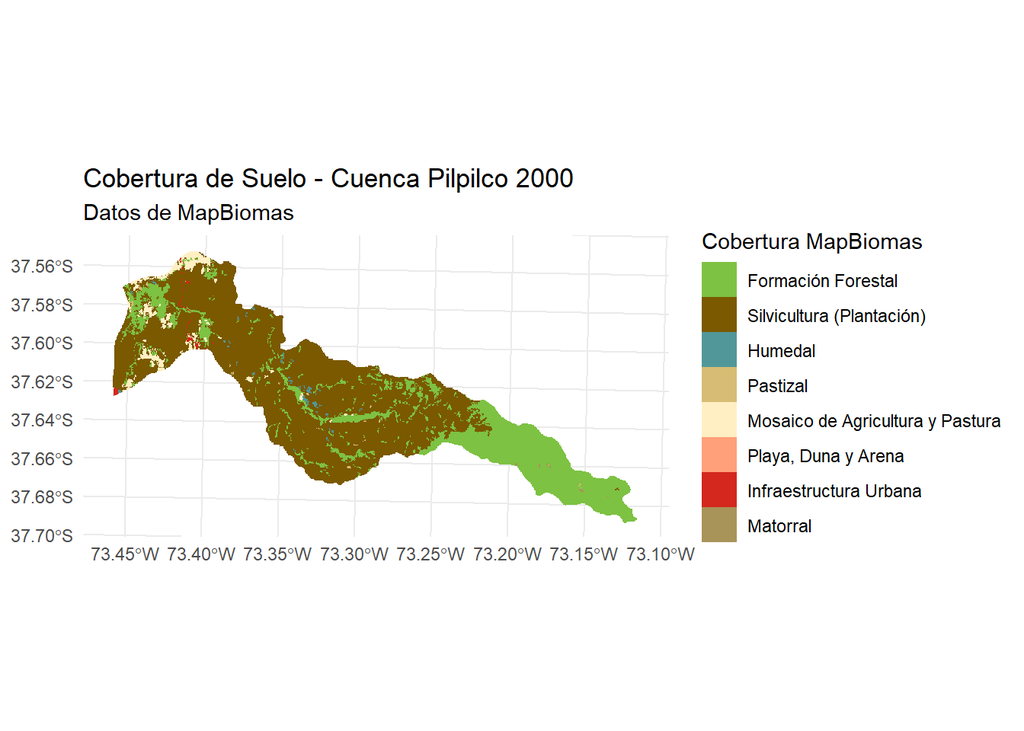

```r
p1
```

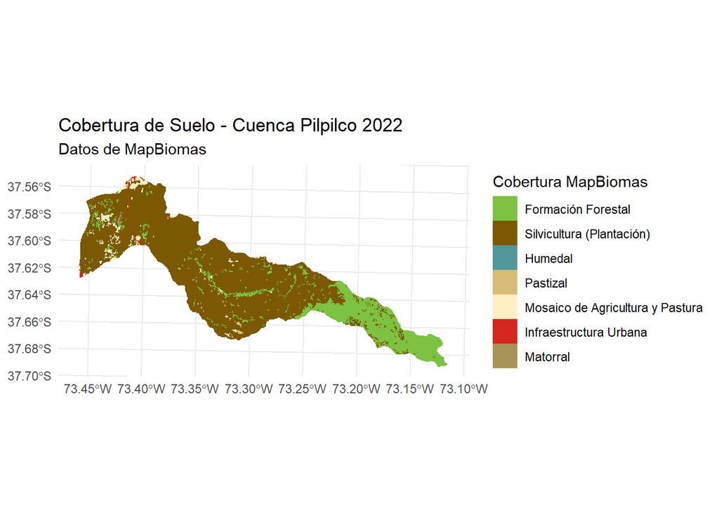

```r
p2
```

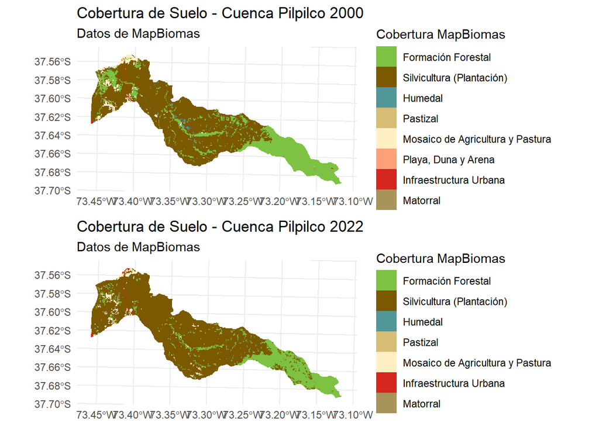

```r
#combinar en uno:
plot_grid(p1, p2, ncol = 1, nrow = 2)
```

**Tip**

Antes de calcular métricas:

- ¿Qué coberturas parecen aumentar?
- ¿Qué coberturas parecen disminuir?
- ¿Dónde observas indicios de fragmentación?

# 9 Análisis a nivel de parche

Un parche corresponde a un conjunto continuo de píxeles de una misma cobertura.

```r
parches_00 <- calculate_lsm(pil_00, level = "patch", metric = c("area", "cai")) %>%
  mutate(year = "2000")
parches_22 <- calculate_lsm(pil_22, level = "patch", metric = c("area", "cai")) %>%
  mutate(year = "2022")

analisis_parches <- bind_rows(parches_00, parches_22) %>%
  left_join(leyenda_completa, by = "class")
```

## 9.1 Tamaño de parches por cobertura

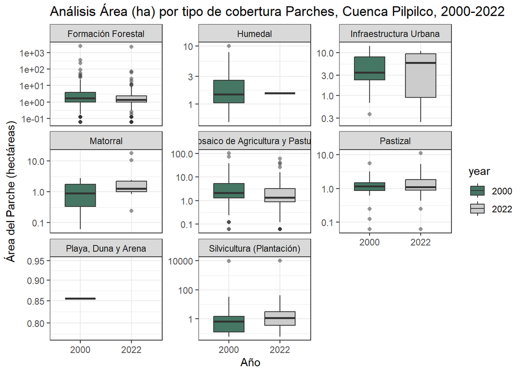

```r
# Gráfico 1: distribución del tamaño de parches para todas las clases
g_parches_todo <- analisis_parches %>%
  filter(metric == "area") %>% # Quitamos el filtro de clases para incluir todas
  ggplot(aes(x = year, y = value, fill = year)) +
  geom_boxplot(outlier.shape = 16, outlier.alpha = 0.5, width = 0.6) +
  scale_y_log10() + # escala logarítmica porque los tamaños varían de <1 ha a miles de ha
  scale_fill_manual(values = c("2000" = "#457764", "2022" = "#cccccc")) +
  facet_wrap(~descripcion, scales = "free_y") + #permite que cada panel adapte su propio eje Y
  theme_bw() +
  labs(
    title = "Análisis Área (ha) por tipo de cobertura Parches, Cuenca Pilpilco, 2000-2022",
    x = "Año",
    y = "Área del Parche (hectáreas)"
  ) +
  theme_bw()

g_parches_todo
```

### 9.1.1 Interpretación

¿Qué observaciones tienes sobre cambios en las métricas?

## 9.2 Formación forestal (Área)

Vamos a observar una cobertura (clase) en particular, al nivel de parche:

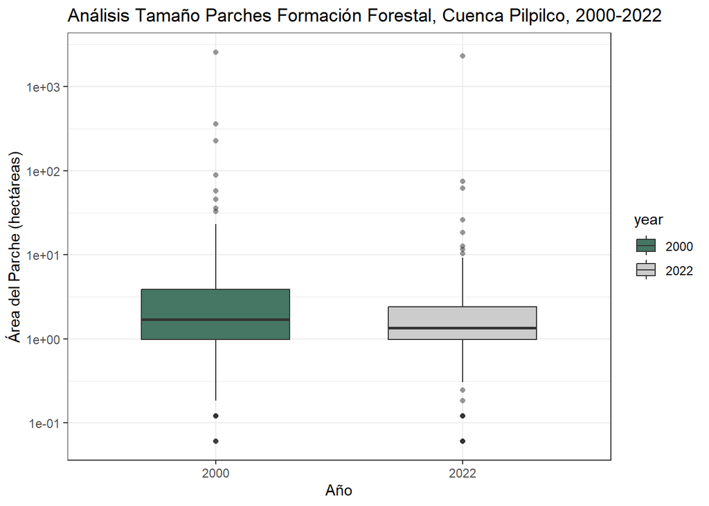

```r
# Gráfico 1a: distribución del tamaño de parches para sola una clase
g_parches_forestal <- analisis_parches %>%
  filter(metric == "area", class == 3) %>% #aqui el codigo de la leyenda, formación forestal
  ggplot(aes(x = year, y = value, fill = year)) +
  geom_boxplot(outlier.shape = 16, outlier.alpha = 0.5, width = 0.6) +
  scale_fill_manual(values = c("2000" = "#457764", "2022" = "#cccccc")) +
  scale_y_log10() +
  theme_bw() +
  labs(
    title = "Análisis Tamaño Parches Formación Forestal, Cuenca Pilpilco, 2000-2022",
    x = "Año",
    y = "Área del Parche (hectáreas)"
  ) +
  theme_bw()

g_parches_forestal
```

## 9.3 Formación forestal, Área núcleo (CAI)

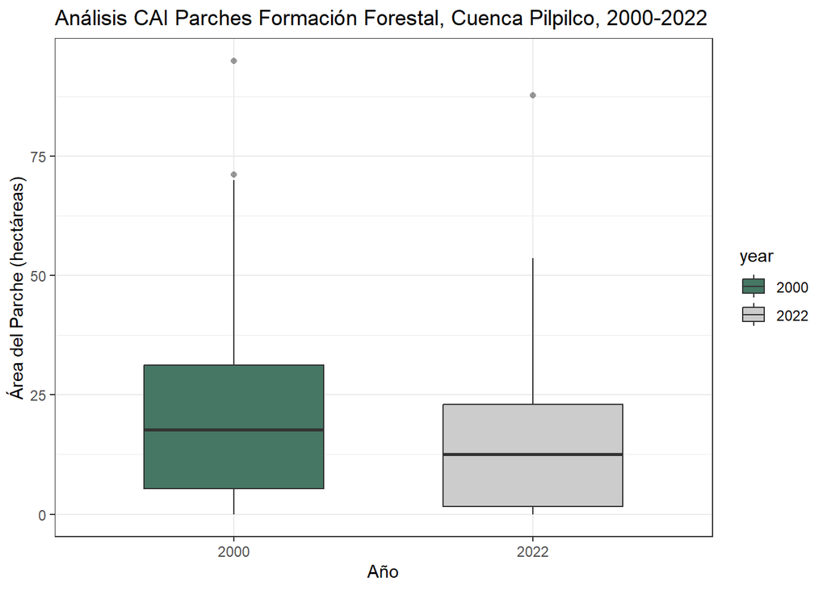

```r
# Gráfico 1b: otra métrica
g_parches_forestal_cai <- analisis_parches %>%
  filter(metric == "cai", class == 3)  %>%
  ggplot(aes(x = year, y = value, fill = year)) +
  geom_boxplot(outlier.shape = 16, outlier.alpha = 0.5, width = 0.6) +
  scale_fill_manual(values = c("2000" = "#457764", "2022" = "#cccccc")) +
  # scale_y_log10() +
  theme_bw() +
  labs(
    title = "Análisis CAI Parches Formación Forestal, Cuenca Pilpilco, 2000-2022",
    x = "Año",
    y = "Área del Parche (hectáreas)"
  ) +
  theme_bw()
g_parches_forestal_cai
```

**Note**

CAI mide la proporción del parche que permanece alejada de los bordes.

# 10 Análisis a nivel de clase

```r
clase_00 <- calculate_lsm(pil_00, level = "class", metric = c("ca", "np", "pland")) %>% mutate(year = "2000")
clase_22 <- calculate_lsm(pil_22, level = "class", metric = c("ca", "np", "pland")) %>% mutate(year = "2022")

analisis_clases <- bind_rows(clase_00, clase_22) %>%
  left_join(leyenda_completa, by = "class")
```

## 10.1 Dominancia del paisaje (PLAND)

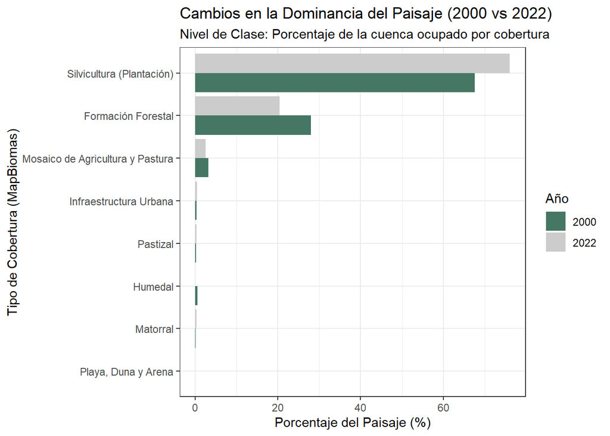

```r
g_clase_pland <- analisis_clases %>%
  filter(metric == "pland") %>%
  ggplot(aes(x = reorder(descripcion, value), y = value, fill = year)) +
  geom_bar(stat = "identity", position = "dodge") +
  coord_flip() +
  scale_fill_manual(values = c("2000" = "#457764", "2022" = "#cccccc")) +
  theme_bw() +
  labs(
    title = "Cambios en la Dominancia del Paisaje (2000 vs 2022)",
    subtitle = "Nivel de Clase: Porcentaje de la cuenca ocupado por cobertura",
    x = "Tipo de Cobertura (MapBiomas)",
    y = "Porcentaje del Paisaje (%)",
    fill = "Año"
  )
g_clase_pland
```

### 10.1.1 Pregunta

¿Qué coberturas ganaron o perdieron importancia relativa?

## 10.2 Evidencia de fragmentación

Un patrón clásico es:

- CA ↓
- NP ↑

```
`geom_line()`: Each group consists of only one observation.
ℹ Do you need to adjust the group aesthetic?
```

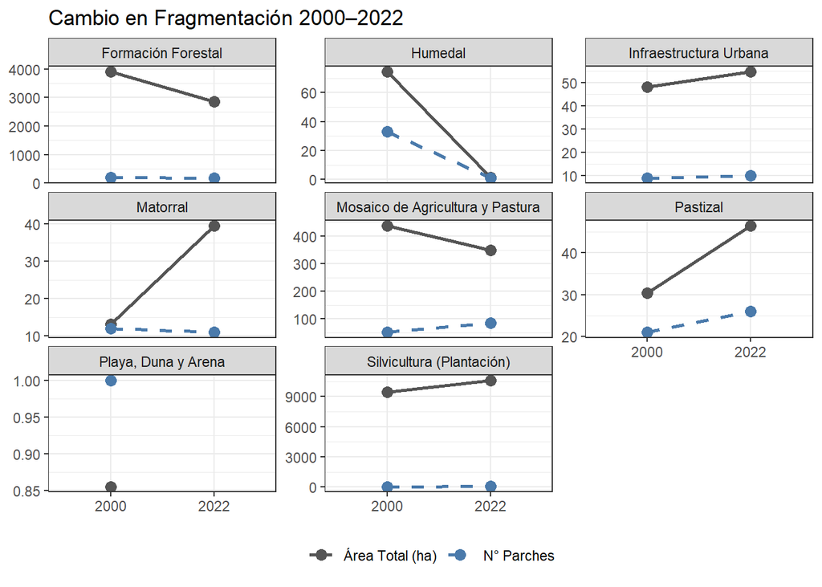

```r
g_clase_frag <- analisis_clases %>%
  filter(metric %in% c("ca", "np")) %>%
  mutate(
    year = as.factor(year),
    value = as.numeric(value),
    metric = recode(metric, ca = "Área Total (ha)", np = "N° Parches")
  ) %>%
  ggplot(aes(x = year, y = value, group = metric, color = metric, linetype = metric)) +
  geom_line(linewidth = 1) +
  geom_point(size = 3) +
  facet_wrap(~descripcion, scales = "free_y") +
  scale_color_manual(values = c("Área Total (ha)" = "#555555", "N° Parches" = "#4a7aab")) +
  scale_linetype_manual(values = c("Área Total (ha)" = "solid", "N° Parches" = "dashed")) +
  theme_bw() +
  labs(
    title = "Cambio en Fragmentación 2000–2022",
    x = NULL, y = NULL, color = NULL, linetype = NULL
  ) +
  theme(legend.position = "bottom")
g_clase_frag
```

# 11 Análisis a nivel de paisaje

```r
paisaje_00 <- calculate_lsm(pil_00, level = "landscape", metric = c("shdi", "np", "pr", "contag")) %>% mutate(year = "2000")
paisaje_22 <- calculate_lsm(pil_22, level = "landscape", metric = c("shdi", "np", "pr", "contag")) %>% mutate(year = "2022")

analisis_paisaje <- bind_rows(paisaje_00, paisaje_22)
```

## 11.1 Resumen numérico

```r
# Crear una tabla comparativa resumida
tabla_paisaje <- analisis_paisaje %>%
  select(metric, value, year) %>%
  pivot_wider(names_from = year, values_from = value) %>%
  mutate(cambio_neto = `2022` - `2000`)
tabla_paisaje
```

```
# A tibble: 4 × 4
  metric  `2000`  `2022` cambio_neto
  <chr>    <dbl>   <dbl>       <dbl>
1 contag  75.4    77.1         1.67
2 np     377     403          26
3 pr       8       7          -1
4 shdi     0.797   0.683      -0.115
```

## 11.2 Cambios en la estructura del paisaje

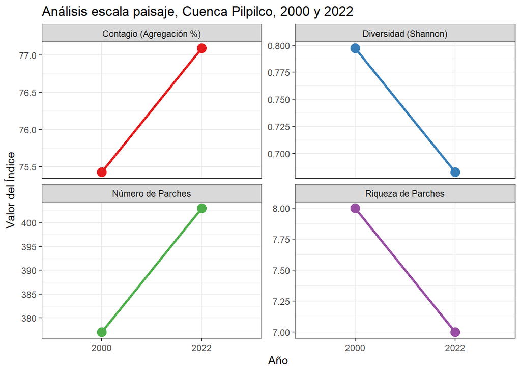

```r
g_paisaje <- analisis_paisaje %>%
  filter(metric %in% c("shdi", "contag", "np", "pr")) %>%
  mutate(
    year = as.factor(year),
    value = as.numeric(value),
    metric = recode(metric, "shdi" = "Diversidad (Shannon)", "contag" = "Contagio (Agregación %)",
                    "np" = "Número de Parches", "pr" = "Riqueza de Parches")
  ) %>%
  ggplot(aes(x = year, y = value, group = metric, color = metric)) +
  geom_line(linewidth = 1.2) +
  geom_point(size = 4) +
  facet_wrap(~metric, scales = "free_y") +
  scale_color_brewer(palette = "Set1") +
  theme_bw() +
  labs(
    title = "Análisis escala paisaje, Cuenca Pilpilco, 2000 y 2022",
    x = "Año",
    y = "Valor del Índice"
  ) +
  theme(legend.position = "none")
g_paisaje
```

### 11.2.1 Guía de interpretación

| Métrica | Significado |
| --- | --- |
| SHDI | Diversidad del paisaje |
| NP | Número total de parches |
| PR | Riqueza de clases |
| CONTAG | Agregación espacial |

# 12 Síntesis final

Completa:

> Entre 2000 y 2022 la cuenca del río Pilpilco se experimentó …

Utiliza:

- una métrica de parche,
- una métrica de clase,
- una métrica de paisaje.